# なぜR?

Toshiki SHIBANO

2021-02-10

## データ分析とは

私はデータ分析は大きく分けて次の6つから成り立っていると考えています．

1. 実験計画
2. データの取得
3. データの整理
4. データの可視化
5. 統計処理(検定，モデリング)
6. 結果の吟味，考察，提案

0と6に関しては解析ツールがほぼ必要なく，自分の頭とペンで行えます(実験計画における乱数などの例外はありますが)．

しかしながら2 ~ 4に関しては，何かしらのツールが必須となっています． 今の時代，グラフを手書きで描くなんてことはほぼ無いでしょう． そのツールとして1番に思い浮かぶのが，Excel (Microsoft) だと思います． 有料ではありますが，非常に素晴らしいツールで世界中で使用されています． マウスでグラフを簡単に描くことができ，さらにピボットテーブルによる強力な集計も可能です． それ以外のツールとして挙げられるのが，SPSS (IBM) やJMP (SAS) といった非常に強力な有料ツール，プログラミング言語になりますが，RやPythonなども有名だと思います．

## R言語とは

Wikipedia (https://ja.wikipedia.org/wiki/R言語) をまとめますと

- 日本語対応
- 様々なOSに対応したオープンソース・**フリー**ソフトウェア
- 作図・統計解析に強い
- 世界中の様々な研究者・データ分析者が利用
- 他人が開発したパッケージ(便利なツール)をDLして使用可能であり，また自分が作って他人に配ることも可能

## なぜRを使うのか

- 無料だから
- バージョンさえ合わせれば，世界中の誰がしても同じ結果が得られるから(再現性)
- 自分で思うがままに高度なこと(データの整理，作図，統計解析)が出来るから
- 世界中の先駆者が便利な機能(パッケージ)を開発していて，それを利用できるから
- Pythonと比較して使い始めるまでが簡単(と思います)

## R Markdownのススメ

Rはスクリプトファイル(メモ帳みたいなもの)に書いて実行することが多いと思います． しかしながら，非常に便利なR Markdownというものがあります． 私も最近使い始めました(これもR Markdownで書いてます)．なぜ便利なのか，一言でまとめるなら

**(実験計画→データの取得→)データの処理→可視化→統計解析→考察を一つのファイルで行える**

に尽きると思います． Wordなどと行ったり来たりする必要がありませんし，解析したコードもそのまま載せることができます． パワーポイントもそのまま出力できるとか・・・？ 初めは使い慣れるのに時間がかかるかもしれませんが，ぜひマスターしていただきたいです．

## 解析例

Rで解析例を載せます．データは架空です．

内容 ジャガイモ3品種(A, B, C)の収量の差を調べたい． そこで研究室で管理している圃場を用いて，乱塊法(4反復)で試験した． 1試験区あたりの面積は$10 m^2$である． その収量の結果をyield.csvにまとめた．

注意点: Rでデータを読み込ませて扱う場合，tidyデータが必要である場合が多いです． tidyデータとは

- 各変数が独立したデータであること
- 観測した値は1行に記録される
- 観測データの集合はテーブルを表現する

わかりにくいと思いますが，すぐに慣れると思います

実際に行っていきます．

```r
# ディレクトリの設定が必要なら行う
# getwd()
# setwd()
# もしくはSession → Set Worling Directory → Choose Directory

# 試験区設定
set.seed(seed = 0) # 乱数の固定
# それぞれのブロックでA, B, Cをランダムに配置する
b1 <- sample(x = c("A", "B", "C"), size = 3, replace = FALSE)
# 与えた条件(x引数)の中から全てサンプリングするならsize引数を与えなくて良い
b2 <- sample(c("A", "B", "C"), replace = FALSE)
b3 <- sample(c("A", "B", "C"), replace = FALSE)
b4 <- sample(c("A", "B", "C"), replace = FALSE)

# 行列をフィールドに見立てる
test_field <- matrix(c(b1, b2, b3, b4), ncol = 3)
colnames(test_field) <- c("", "", "" ) # 列の名前
rownames(test_field) <- c("b1", "b2", "b3", "b4") # 行の名前

# test_field
knitr::kable(test_field, format = "pandoc")
```

| b1 | B | A | B |
| --- | --- | --- | --- |
| b2 | A | B | B |
| b3 | C | A | C |
| b4 | C | C | A |

```r
# データの読み込み
# OSによってコードが変わる
yield <- read.csv(file = "yield.csv", header = TRUE)

# データの表示
# R Markdownで出力を整えるためのコード
#yield
# で良い
knitr::kable(yield, format = "pandoc")
```

| variety | block | yield |
| --- | --- | --- |
| A | 1 | 312.6295 |
| A | 2 | 296.7377 |
| A | 3 | 313.2980 |
| A | 4 | 312.7243 |
| B | 1 | 264.1464 |
| B | 2 | 244.6005 |
| B | 3 | 250.7143 |
| B | 4 | 257.0528 |
| C | 1 | 249.9423 |
| C | 2 | 274.0465 |
| C | 3 | 257.6359 |
| C | 4 | 242.0099 |

```r
# variety列とblock列をcharacter型からfactor型に変更する
# 後のTukeyHSDを使った多重比較のため
yield$variety <- factor(yield$variety)
yield$block <- factor(yield$block)
```

```r
# 作図
library(tidyverse)
```

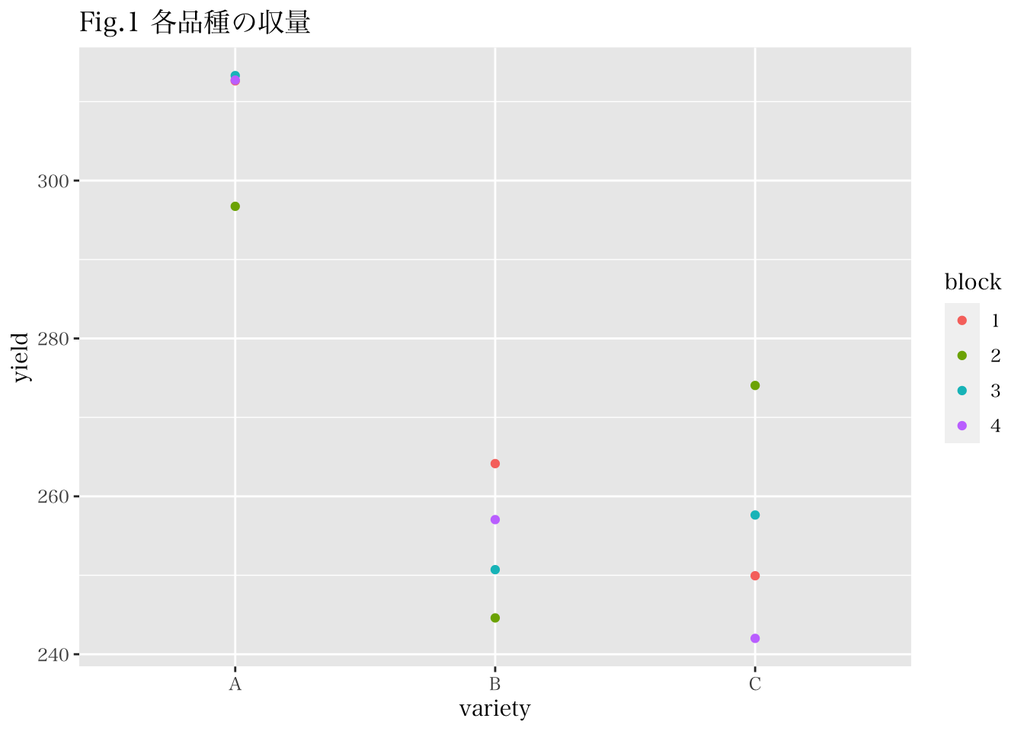

```r
# 日本語フォントを表示出来るように設定
theme_set(theme_gray(base_family = "HiraMinProN-W3"))
# ポストフォントスクリプトのデータベースにフォントファミリ"HiraMinProN-W3"が見つかりません
# という警告が出てるけど，いけてるからヨシ！
# 原因が分からないので調べておきます．

# x軸に品種，y軸に収量
p <- ggplot(data = yield,
            mapping = aes(x = variety, y = yield))
p1 <- p + geom_point(mapping = aes(color = block)) +
    labs(title = "Fig.1 各品種の収量")
p1
```

```r
# データの集計
# 品種ごとに平均および標準偏差を求める
yield_by_variety <-
  yield %>%
  group_by(variety) %>%
  summarise(N = n(),
            mean = mean(yield),
            sd = sd(yield),
            .groups = "drop")

# R Markdownで出力を整えるためのコード
# yield_by_variety
# で良い
knitr::kable(yield_by_variety, format = "pandoc")
```

| variety | N | mean | sd |
| --- | --- | --- | --- |
| A | 4 | 308.8474 | 8.078538 |
| B | 4 | 254.1285 | 8.393439 |
| C | 4 | 255.9087 | 13.671605 |

```r
p <- ggplot(data = yield_by_variety,
            mapping = aes(x = mean, y = variety, color = variety))

p2 <- p + geom_pointrange(mapping = aes(xmin = mean-sd, xmax = mean+sd)) +
    guides(color = FALSE) +
    labs(x = "yield", title = "Fig.2 各品種の平均収量(±SD)")

# ブロックごとに平均および標準偏差を求める
yield_by_block <-
  yield %>%
  group_by(block) %>%
  summarise(N = n(),
            mean = mean(yield),
            sd = sd(yield),
            .groups = "drop")
# R Markdownで出力を整えるためのコード
# yield_by_variety
# で良い
knitr::kable(yield_by_block, format = "pandoc")
```

| block | N | mean | sd |
| --- | --- | --- | --- |
| 1 | 3 | 275.5728 | 32.86857 |
| 2 | 3 | 271.7949 | 26.14141 |
| 3 | 3 | 273.8828 | 34.30959 |
| 4 | 3 | 270.5957 | 37.25169 |

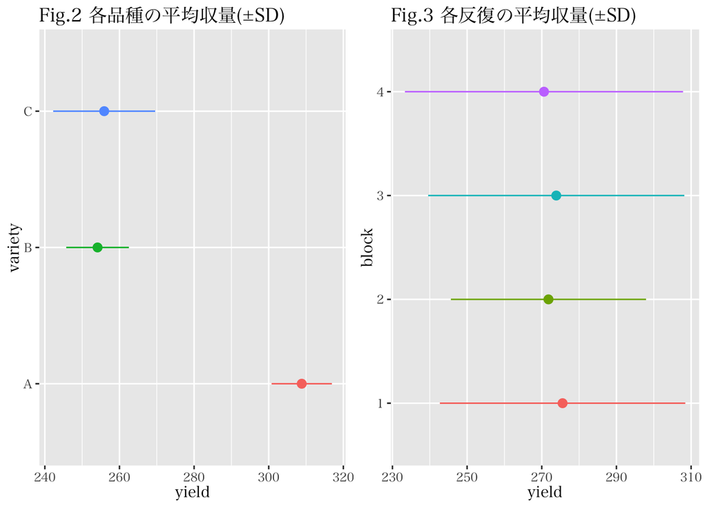

```r
p <- ggplot(data = yield_by_block,
            mapping = aes(x = mean, y = block, color = block))
p3 <- p + geom_pointrange(mapping = aes(xmin = mean - sd, xmax = mean + sd)) +
    guides(color = FALSE) +
    labs(x = "yield", title = "Fig.3 各反復の平均収量(±SD)")

p_all <- ggpubr::ggarrange(p2, p3)
p_all
```

実際に検定をかけよう．乱塊法を使ってるので分散分析を行う

```r
# 乱塊法を行う
# 交互作用は考えない
anova_RB <- aov(yield ~ variety + block, data = yield)

# R Markdownで出力を整えるためのコード
# anova_RB
# でよい
res_RB <- broom::tidy(anova_RB)
knitr::kable(res_RB, format = "pandoc")
```

| term | df | sumsq | meansq | statistic | p.value |
| --- | --- | --- | --- | --- | --- |
| variety | 2 | 7733.10504 | 3866.55252 | 25.107495 | 0.0012159 |
| block | 3 | 43.87657 | 14.62552 | 0.094971 | 0.9600323 |
| Residuals | 6 | 923.99960 | 153.99993 | NA | NA |

```r
res_tukey <- TukeyHSD(aov(yield$yield ~ yield$variety))

# R Markdownで出力を整えるためのコード
# res_tukey
# でよい
knitr::kable(data.frame(res_tukey$`yield$variety`), format = "pandoc")
```

|  | diff | lwr | upr | p.adj |
| --- | --- | --- | --- | --- |
| B-A | -54.718864 | -75.19226 | -34.24547 | 0.0001018 |
| C-A | -52.938698 | -73.41210 | -32.46530 | 0.0001317 |
| C-B | 1.780166 | -18.69323 | 22.25356 | 0.9681473 |

AとB，AとCに有意差があり，BとCには有意差がなかった．

今回のような圃場条件では，Aが一番取れる品種だろう．

有意差の結果を踏まえてもう一度グラフを描く

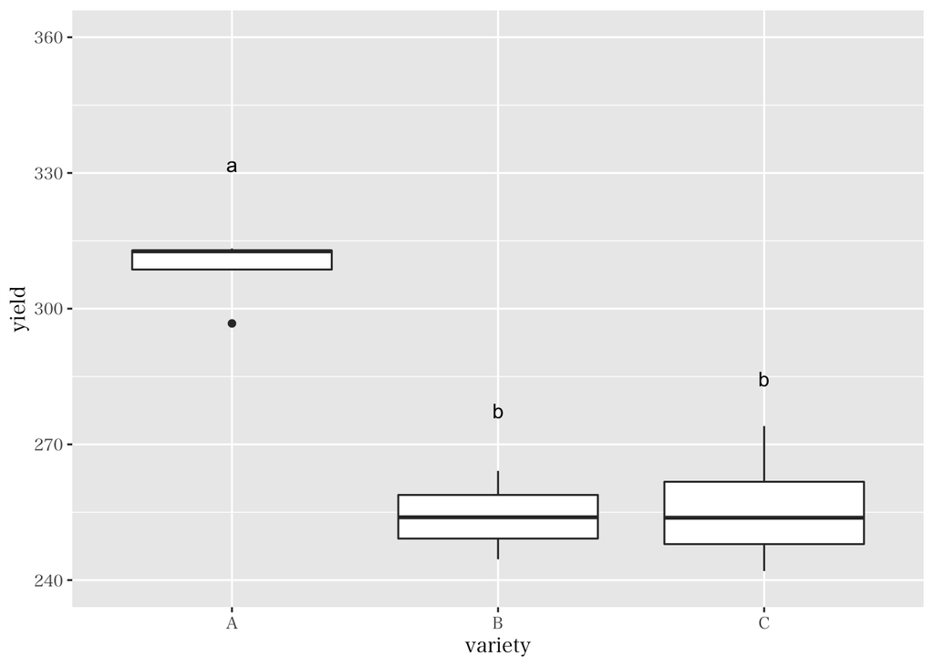

```r
# 箱ひげ図
p <-  ggplot(data = yield,
           mapping = aes(x = variety, y = yield))
# annotateはプロットに文字を描くための関数です
# 文字の場所を決める
position_text <- yield_by_variety$mean + yield_by_variety$sd + 15
p + geom_boxplot() +
    scale_y_continuous(limits = c(240, 360)) +
    annotate("text", x = "A", y = position_text[1], label = "a") +
    annotate("text", x = "B", y = position_text[2], label = "b") +
    annotate("text", x = "C", y = position_text[3], label = "b")
```

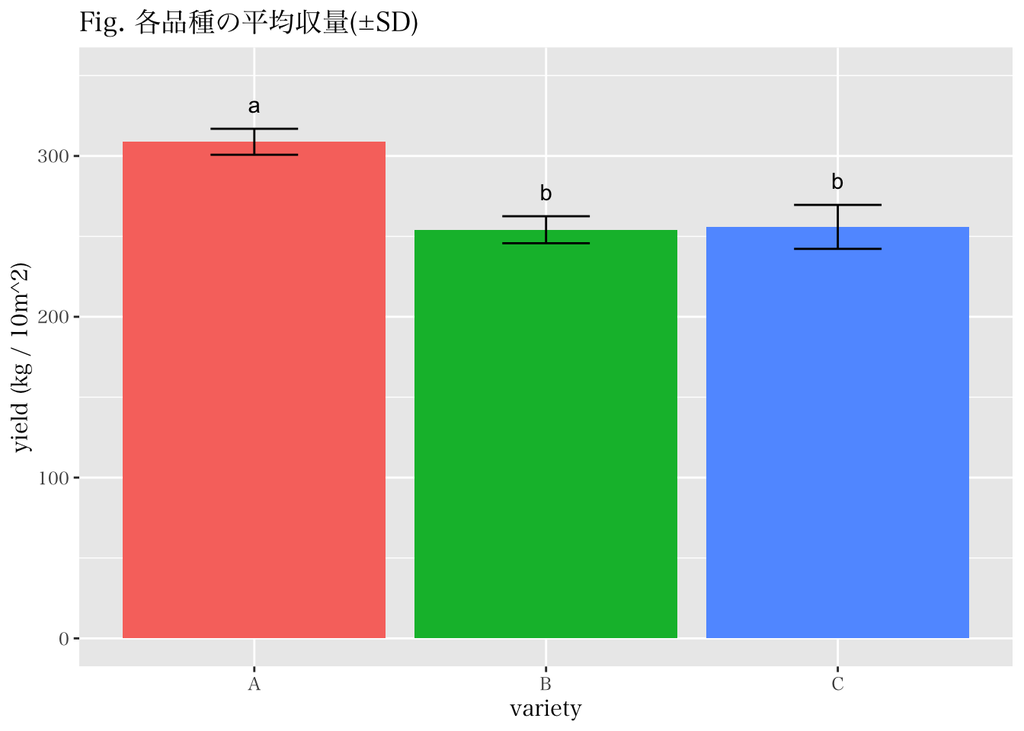

```r
# 棒グラフ
p <- ggplot(data = yield_by_variety,
            mapping = aes(x = variety, y = mean, fill = variety))
position_text <- yield_by_variety$mean + yield_by_variety$sd + 15
p + geom_col() +
    geom_errorbar(mapping = aes(ymin = mean-sd, ymax = mean+sd), width = 0.3) +
    scale_y_continuous(limits = c(0, 350)) +
    annotate("text", x = "A", y = position_text[1], label = "a") +
    annotate("text", x = "B", y = position_text[2], label = "b") +
    annotate("text", x = "C", y = position_text[3], label = "b") +
    labs(y = "yield (kg / 10m^2)",
         title = "Fig. 各品種の平均収量(±SD)") +
    theme(legend.position = "")
```

## 補足

今回のデータはRを使って作成しました．

品種A, B, Cについて

- A: 平均300，標準偏差10の正規分布
- B: 平均260，標準偏差10の正規分布
- C: 平均250，標準偏差10の正規分布

です．ブロック間で変動はもうけていません．

```r
set.seed(seed = 0)
va <- rnorm(n = 4, mean = 300, sd = 10)
vb <- rnorm(n = 4, mean = 260, sd = 10)
vc <- rnorm(n = 4, mean = 250, sd = 10)
# データフレームにまとめる
df <- data.frame("variety" = c(rep("A", 4), rep("B", 4), rep("C", 4)),
                 "block" = c(rep(1:4, 3)),
                 "yield" = c(va, vb, vc))
# csvファイルに書き出し
write.csv(df, "yield.csv", row.names = FALSE)
```

## 文献

おそらくネットを調べればたくさん出てくると思います． 以下私が読んだ，もしくは流し見をして良かった印象がある本をあげます．

Rと統計の本

- Rによるやさしい統計学 by 山田剛史・杉澤武俊・村井潤一郎
- Rによる統計解析 by 青木繁伸
- データ解析のための統計モデリング入門 一般化線形モデル・階層べイズモデル・MCMC by 久保拓哉
- RとStanではじめるベイズ統計モデリングによるデータ分析入門 by 馬場真哉

可視化

- データ分析のためのデータ可視化入門(原文: Data Visualization: A Practical Introduction) by キーラン・ヒーリー (訳: 瓜生真也・江口哲史・三村喬生)
- Google流資料作成術(Rは使ってない) by コール・ヌッスバウマー・ナフリック (訳: 村井瑞枝)

実験計画法など

- 入門実験計画法 by 永田靖
- 統計的多重比較法の基礎 by 永田靖

インターネットサイト

- R Tips (http://cse.naro.affrc.go.jp/takezawa/r-tips/r.html)
- biostatistics (https://stats.biopapyrus.jp)
- Qiita (エラーで困った時やこのグラフどうやって描くんや？って時に行きつくことが多い)

文献などは別の機会にきちんとまとめたいです．